# Designing a Cup

## Problem Description

We would like to design a cup that is shaped like a tapered cylinder. The cup is to be of the following dimensions:

$$height = 100\text{ mm}$$ $$volume = 300\text{ mL}$$

The radii can only have integer milimeters, even if up to $10 \text{ mL}$ of the volume is lost. What should the upper and lower radii be?

It aims to explore the following:

1. Evaluating a function over a region with *itertools.product()*
2. Searching within lists with *list.index()* for values that satisfy certain conditions.
3. Root Finding: *scipy.optimize.root()*

## 1. Evaluating a function over a region with *itertools.product()*

This is typical application when evaluating a function of two variables $f(x,y)$ such as the volume of a tapered cylinder:

$$V(r,R)=\frac{\pi l}{3}(R^2+Rr+r^2)$$

See previous posts for volume calculation.

```python
from math import*
import itertools

# Looking for solutions in range(x1,x2)
r=[j for j in range(18,42)]
R=r
g=itertools.product(r,R) # this is like a nested for-loop

l=100 #mm

rr,RR,VV=[],[],[] #lists: rr for the small radius, RR for the large radius, VV for volume
vdiff=[]
for k in g:
    r=k[0] #element
    rr.append(r) #list
    R=k[1]
    RR.append(R)
    V=pi*l/3*(R**2+r*R+r**2) ## mm^3
    VV.append(V)
    vdiff.append(abs(V/1000-300)) #deviation from desired volume
    #print(' {:6.2f}   {:6.2f}   {:6.2f} {:6.2f}'.format(r,R,V/1000,abs(V/1000-300))) #mL
```

## 2. Searching within Lists

Searching with the *list.index()* method returns the first value that satifies the condition you set. Which is good for things like getting the closest point to the desired volume.

```python
# closest point to desired volume
condition=min(vdiff)
index=vdiff.index(condition)
print('\nThe closest value to 300 mL is:')
print('r={} mm  R={} mm  V={:6.2f} mL'.format(rr[index],RR[index],VV[index]/1000))
```

```
The closest value to 300 mL is:
r=22 mm  R=39 mm  V=299.81 mL
```

### Caution: The *list.index()* Method

Be careful, it only returns the **first index that satisfy a value**.

So, what if we want multiple values, such as all values within 10 mL from the desired volume?

```python
print('Total datapoints')
print(len(vdiff))

indices=[]
for j in vdiff:
    if j<10: #"condition"
        indices.append(vdiff.index(j)) #get the index that satisfies "condition" in vdiff
        vdiff[vdiff.index(j)]=vdiff[vdiff.index(j)]+1000 #altered the value so i can search for the next index

for j in indices:
    vdiff[j]=vdiff[j]-1000 #restored altered value to what it was

datapoints=[]
for j in indices:
    datapoint=(j,rr[j],RR[j],VV[j]/1000,vdiff[j]) #get the datapoints at the indices that satisfy "condition"
    datapoints.append(datapoint)

print('Total datapoints satisfying "condition"')
s=set(datapoints)
if (len(s)==len(datapoints)):
    print('{} unique points'.format(len(s)))
else:
    print('check your data!')

#for j in datapoints: # to view the data
    #print(j)
```

```
Total datapoints
576
Total datapoints satisfying "condition"
45 unique points
```

### Plot 1

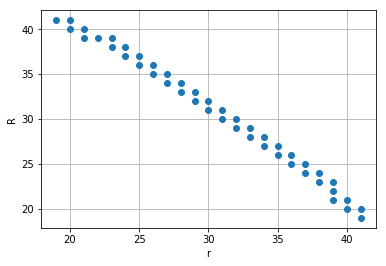

```python
import matplotlib.pyplot as plt

# extract datapoints
x=[]
y=[]
for u in datapoints:
    x.append(u[1])
    y.append(u[2])

x=[u[1] for u in datapoints]
y=[u[2] for u in datapoints]

# plot 1

plt.plot(x,y,'o')
plt.grid()
plt.xlabel('r')
plt.ylabel('R')
plt.show()
```

## 3. Root Finding: *scipy.optimize.root()*

What if we want to know the exact solution at $r$?

```python
from scipy.optimize import root

def f(R):
    return pi*l/3*(R**2+R*r+r**2)-300000

y2=[]
for u in datapoints:
    r=u[1]
    sol=root(f,20) #solves the quadratic eq
    y2.append(sol.x[0])  #takes the positive root
```

### Plot 2

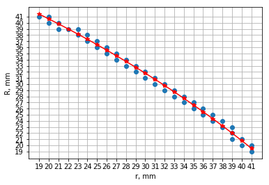

```python
# plot 2

plt.plot(x,y,'o')
plt.plot(x,y2,'-*r')
plt.grid()
plt.xlabel('r, mm')
plt.ylabel('R, mm')
plt.xticks(range(19,42))
plt.yticks(range(19,42))
plt.show()
```